# 04 Poisson Distribution

Robert C Cline Sr

2022-04-15

#### A model with a Poisson distribution

#### [Link here to OurCodingClub Modeling Tutorial](https://ourcodingclub.github.io/tutorials/modelling/)

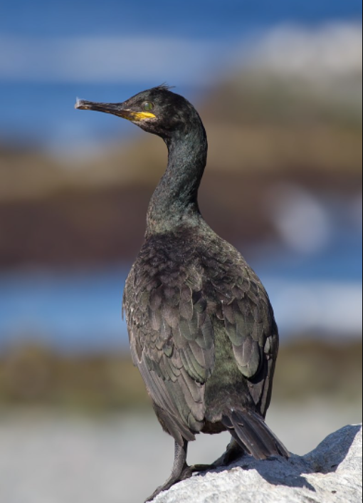

*Gulosus aristolesis*, cormorant

#### Import shagLIP.csv dataset[^1]

- data represent population trends for European Shags on the Isle of May and are available from the Living Planet Index.

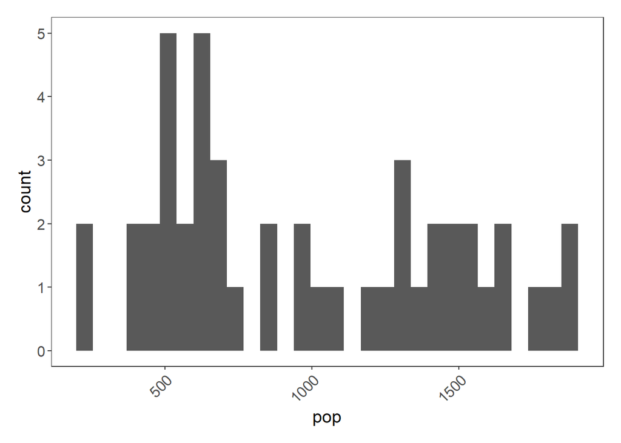

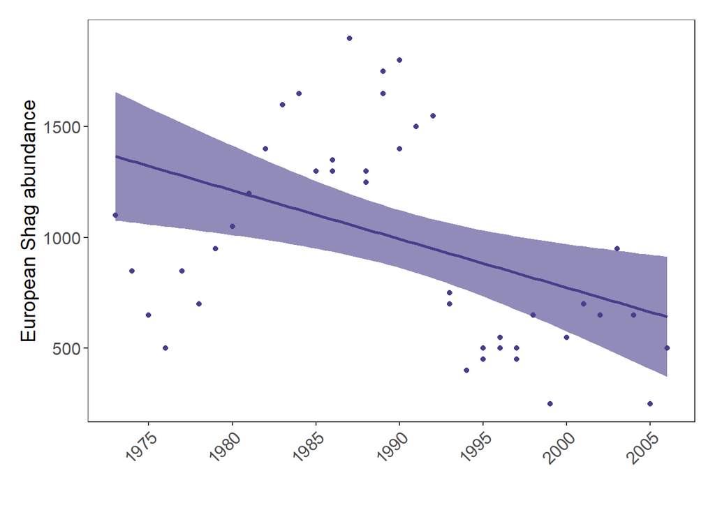

### A model with a binomial distribution.

- binomial is not linear.
- binomial models are **logistic regression** which rely on **log odd ratios**.
- There is no **R squared value** to assess **goodness of fit**.
- Assess goodness of fit by looking at the difference between:
  - `Null deviance` (variability explained by a null model; e.g. glm(damage_T_F ~ 1)) and
  - `Residual deviance` e.g. the amount of variability that remains after you have eplained the explanitory variable.

Weevil_damage.csv: Damage to Scot’s pine by weevils. Perhaps some blocks of pines witll be particularly vulnerable to weevils?

```
##
## Call:  glm(formula = damage_T_F ~ block, family = binomial, data = Weevil_damage)
##
## Coefficients:
## (Intercept)       block2       block3       block4
##      1.5672      -0.8471       0.6841      -0.8740
##
## Degrees of Freedom: 671 Total (i.e. Null);  668 Residual
## Null Deviance:       728.2
## Residual Deviance: 686.6     AIC: 694.6
```

**It looks like the probability of a pine tree enduring damage from weevils does vary significantly based on the block in which the tree was located.**

**Table 1.** *Odds Ratios* [^2] [^3]

|  | damage T F |  |  |
| --- | --- | --- | --- |
| Predictors | Odds Ratios | CI | p |
| (Intercept) | 4.79 | 3.26 – 7.29 | **<0.001** |
| block [2] | 0.43 | 0.25 – 0.71 | **0.001** |
| block [3] | 1.98 | 1.04 – 3.88 | **0.040** |
| block [4] | 0.42 | 0.25 – 0.69 | **0.001** |
| Observations | 672 |  |  |
| R<sup>2</sup> Tjur | 0.058 |  |  |

Greater estimates still mean bigger influence of your variables, just keep in mind that it’s not a linear relationship! And finally, you won’t get a R squared value to assess the goodness of fit of your model, but you can get at that by looking at the difference between the Null deviance (variability explained by a null model, e.g. glm(damage_T_F ~ 1)) and the Residual deviance, e.g. the amount of variability that remains after you’ve explained some away by your explanatory variable. In short, the bigger the reduction in deviance, the better a job your model is doing at explaining a relationship.

**Table 2.** Null deviance vs. Residual deviance.[^4]

|  | damage T F |  |  | damage T F |  |  |
| --- | --- | --- | --- | --- | --- | --- |
| Predictors | Odds Ratios | CI | p | Odds Ratios | CI | p |
| (Intercept) | 4.79 | 3.26 – 7.29 | **<0.001** | 3.31 | 2.77 – 3.96 | **<0.001** |
| block [2] | 0.43 | 0.25 – 0.71 | **0.001** |  |  |  |
| block [3] | 1.98 | 1.04 – 3.88 | **0.040** |  |  |  |
| block [4] | 0.42 | 0.25 – 0.69 | **0.001** |  |  |  |
| Observations | 672 |  |  | 672 |  |  |
| R<sup>2</sup> Tjur | 0.058 |  |  | 0.000 |  |  |

[^1]: Living Planet Index. (n.d.). Retrieved April 15, 2022, from https://livingplanetindex.org/home/index
[^2]: The output with sjplot() is in *Odds Ratios*. The coefficients are automatically exponentiated.
[^3]: For Explanation of sjplot() output for glm(), C.f. https://strengejacke.github.io/sjPlot/articles/tab_model_estimates.html
[^4]: See explanation of **A model with binomial distribution** https://ourcodingclub.github.io/tutorials/modelling/